# Statistical Analysis - Part II

## Regression

General steps for building a regression model:

- Start with a hypothesis or specific goal (e.g. predicting BMI from age)
- Identify the feature you want to predict, the response variable (e.g. BMI)
- Identify the predictors - age, sex, heart rate (the input data)
- Do you expect a linear relationship?
- Visualize variables using plot functions

### Regression - Creating a Model

When creating a regression model, it is helpful to start with the simplest model (single variable) and then gradually increase the complexity.

Simple linear regression is used for the two-variable models. With linear regression, we examine the explanatory variable and the response variable, and try to fit a linear equation to the data: , where is the predicited value and b is the regression coefficient.

Can we predict BMI from total cholesterol? There are two ways to find the slope (regression coefficient) of single-variable linear regression models.

(If you need to recreate the tables from Part I of the lecture, you can run the below code)

```matlab
fram = readtable("../frmgham.xls");
fram_2_11 = fram(:,2:11);
fram_noNaN = rmmissing(fram_2_11);
```

1.) Use the \ operator. The data sets must not contain any missing values, so we must use the table we created using the rmmissing function.

```matlab
fram_noNaN.TOTCHOL \ fram_noNaN.BMI
```

ans = 0.1037

2.) Use the regress function. The regress function removes NaN values for us, so we can use the original data. Before carrying out the command, assign the total cholesterol and BMI arrays to variables X and Y, respectively.

```matlab
X = fram.TOTCHOL;
Y = fram.BMI;
b = regress(Y,X)
```

b = 0.1038

These two methods should produce the same results for b. In terms of predicting BMI from total cholesterol, we now have the equation , where is estimated BMI, b is the regression coefficient, and X is total cholesterol. Create an array containing the predicted BMI values using this equation.

```matlab
Y1 = b*X;
```

To improve the regression model, we want to include an intercept term. In order to do this, a column of ones must be added to independent variable matrix.

```matlab
X_ones = [ones(size(X)) X];
```

Now repeat the regress command with the new X_ones variable.

```matlab
b2 = regress(Y,X_ones)
```

b2 = 2×1

24.1091 0.0072

The first term in the b array is the y-intercept for the linear regression line, and the second term is the slope. We now have the equation . Use these values to create an array which contains the new values for .

```matlab
Y2 = b2(2)*X_ones(:,2)+b2(1);
```

How do the two estimates for compare? And how do these compare to that actual BMI data? Use the scatter function to compare. Also, calculate the value for each relationship.

```matlab
subplot(2,2,1)
scatter(X,Y1)
xlabel('Total Cholesterol')
ylabel('Predicted BMI')
title('Cholesterol vs Predicted BMI')
R_squared_1 = corr(X,Y1,"rows","complete")^2
```

R_squared_1 = 1

```matlab
text(200,50,['R^2 = ' num2str(R_squared_1)])

subplot(2,2,2)
scatter(Y,Y1)
xlabel('Actual BMI')
ylabel('Predicted BMI')
title('Actual vs Predicted BMI')
R_squared_2 = corr(Y,Y1,"rows","complete")^2
```

R_squared_2 = 0.0064

```matlab
text(50,60,['R^2 = ' num2str(R_squared_2)])

subplot(2,2,3)
scatter(X,Y2)
xlabel('Total Cholesterol')
ylabel('Predicted BMI')
title('Cholesterol vs Predicted BMI (w/ Intercept)')
R_squared_3 = corr(X,Y2,"rows","complete")^2
```

R_squared_3 = 1

```matlab
text(300,28,['R^2 = ' num2str(R_squared_3)])

subplot(2,2,4)
scatter(Y,Y2)
xlabel('Actual BMI')
ylabel('Predicted BMI')
title('Actual vs Predicted BMI (w/ Intercept)')
R_squared_4 = corr(Y,Y2,"rows","complete")^2
```

R_squared_4 = 0.0064

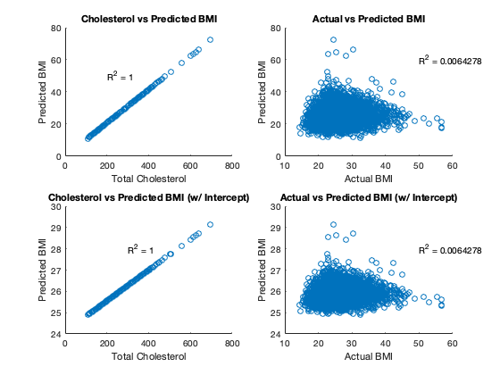

```matlab
text(50,28,['R^2 = ' num2str(R_squared_4)])
```

Note that the axes limits vary in the above plots.

### Regression Model - Forecasting

We can use the regression model to predict impact in new conditions.

Predict the BMI for a hypothetical person with a total cholesterol value of 200.

```matlab
BMI_200 = b2(2)*200 + b2(1)
```

BMI_200 = 25.5538

### Regression - Predicting New Values

Using the regression coefficient, we can examine how the predicted BMI changes with total cholesterol. For example, make an array of values from the minimum to maximum cholesterol values in increments of 10.

```matlab
chol_range = min(X):10:max(X);
```

Create an array which contains the corresponding predicted BMI values.

```matlab
Y1_predict = b2(2)*chol_range+b2(1);
```

Create a scatter plot with the new.

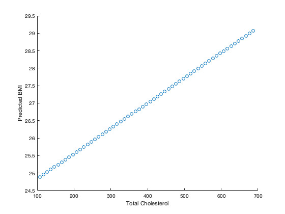

```matlab
figure
scatter(chol_range,Y1_predict)
xlabel('Total Cholesterol')
ylabel('Predicted BMI')
```

We can also insert a best fit line on the original data set using the lsline function.

```matlab
scatter(X,Y)
xlabel('Total Cholesterol')
ylabel('BMI')
h = lsline;
h.Color = 'r';
```

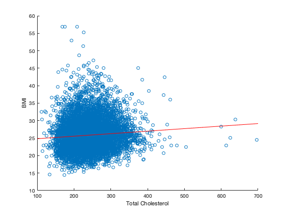

Another method for performing linear regression uses the fitlm function. The fitlm function outputs a linear regression model when given the predicting variable and the response variable.

```matlab
fitlm(X,Y)
```

ans =

Linear regression model: y ~ 1 + x1 Estimated Coefficients: **Estimate** **SE** **tStat** **pValue** **_________** **__________** **______** **__________** **(Intercept)** 24.109 0.20852 115.62 0 **x1** 0.0072236 0.00084972 8.5012 2.1157e-17 Number of observations: 11173, Error degrees of freedom: 11171 Root Mean Squared Error: 4.07 R-squared: 0.00643, Adjusted R-Squared: 0.00634 F-statistic vs. constant model: 72.3, p-value = 2.12e-17

The intercept and regression coefficient terms from the fitlm function give us the same equation for the best fit line as when we used the regress function:

### Regression - Systolic and Diastolic BP

Create a linear model which uses systolic blood pressure to predict diastolic blood pressure. Plot the data points, the best fit line and find the linear regression equation.

```matlab
scatter(fram.SYSBP,fram.DIABP)
xlabel('Systolic BP')
ylabel('Diastolic BP')
h = lsline;
h.Color = 'r';
```

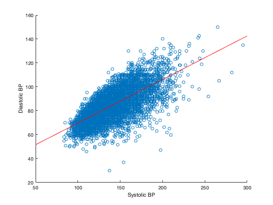

```matlab
fitlm(fram.SYSBP,fram.DIABP)
```

ans =

Linear regression model: y ~ 1 + x1 Estimated Coefficients: **Estimate** **SE** **tStat** **pValue** **________** **_________** **______** **______** **(Intercept)** 33.421 0.46061 72.558 0 **x1** 0.36396 0.0033325 109.22 0 Number of observations: 11627, Error degrees of freedom: 11625 Root Mean Squared Error: 8.19 R-squared: 0.506, Adjusted R-Squared: 0.506 F-statistic vs. constant model: 1.19e+04, p-value = 0

The equation for the best fit line is The positive slope indicates that diastolic blood pressure increases with systolic blood pressure. The value of 0.506 indicates that there is a fairly strong linear relationship between the two variables.

## Multi-linear Regression

Most diseases and biomedical processes involve multiple parameters. In these instances, several variables may be needed to accurately predict the response variable.

For example, BMI may be a function of age, sex, glucose, cholesterol and heart rate. The regress function can still be used for multi-linear regression models. To create a linear regression model with these variables, we will make a matrix containing all of the predictors plus the column of ones.

```matlab
X_multi = [ones(size(fram.AGE)), fram.AGE, fram.SEX, fram.TOTCHOL, fram.GLUCOSE,...
fram.HEARTRTE];
Y_multi = fram.BMI;
b_multi = regress(Y_multi,X_multi)
```

b_multi = 6×1

22.3565 0.0148 -0.7409 0.0074 0.0113 0.0141

What do the outputs of the regress function tell us about our model? These values are the regression weights and correspond to the effect of each independent variable on the dependent variable.

Most of the features have positive correlations with BMI. We expect for BMI to increase with age, total cholesterol, glucose levels and heart rate. However, our model indicates that BMI decreases with the value for sex (1 for males, 2 for females). This suggests that on average, males have higher BMI than females.

### Multi-linear Regression - Assess Accuracy

To obtain more information about the linear regression model when using the regress command, use the stats option. This option provides the statistic, F-statistic, p-value, and estimated error variance.

Find the value for the single-variable and multi-variable regression models that we made for predicting BMI from total cholesterol.

```matlab
[b,~,~,~,stats] = regress(Y,X_ones);
b
```

b = 2×1

24.1091 0.0072

```matlab
stats(1)
```

ans = 0.0064

```matlab
[b_multi,~,~,~,stats_multi] = regress(Y_multi,X_multi);
b_multi
```

b_multi = 6×1

22.3565 0.0148 -0.7409 0.0074 0.0113 0.0141

```matlab
stats_multi(1)
```

ans = 0.0235

The value increased from 0.0064 to 0.0235 from the single-variable model to the multi-variable model.

While both values are very low, it makes sense that the value for the multi-variable linear regression is higher as we have more predicting factors for the BMI.

## Logistic Regression

Logistic regression is used for discrete categorical data (in contrast to continuous data for linear regression).

Example – Classifying patients with diabetes versus those without diabetics.

Similar to the regress and fitlm functions, we can use the mnrfit function to predict diabetes from multiple variables. The mnrfit command returns a matrix of coefficient estimates for a multinomial logistic regression of the response variable based on the predictor variables.

Note that the response variable must be discrete, but the predictors can be continuous. We will start with just one predictor, blood glucose levels.

First, the diabetes data set must be converted to a categorical array.

```matlab
diabetes = categorical(fram.DIABETES);
```

The first category is non-diabetic, represented by 0's. The second and last category is diabetic, represented by 1's. The mnrfit function will always use the last category as the "reference" category. The model that is returned by the function indicates the risk of being non-diabetic versus diabetic. This is especially important to remember when there are more than two categories in the response variable.

Now that we have the categorical response variable, we can use mnrfit to create the model.

```matlab
[B1,~,stats] = mnrfit(fram.GLUCOSE, diabetes);
B1
```

B1 = 2×1

8.5446 -0.0565

The first value in B1 contains the intercept term for the relative risk model. The second row contains the slope corresponding to glucose levels. This model for relative risk can be represented by the following equation:

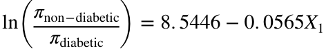

The model coefficients provide information about the relative risk of being in one category versus another. In this example, the coefficient -0.0565 indicates that the relative risk of being non-diabetic versus diabetic decreases exp(0.0565) for every each unit increase in glucose, if all else is equal.

Now include glucose, BMI and total cholesterol in the predictor data set.

```matlab
predictors = [fram.GLUCOSE, fram.BMI, fram.TOTCHOL];
[B1,~,stats] = mnrfit(predictors,diabetes);
B1
```

B1 = 4×1

10.6017 -0.0567 -0.0670 -0.0009

This model for relative risk can be represented by the following equation:

where is glucose, is BMI, and is total cholesterol.

We can also check if each model coefficient is statistically significant.

```matlab
stats.p
```

ans = 4×1

0.0000 0.0000 0.0000 0.4599

We typically look for a p-value below 0.05 for determining whether the hypothesis is significant or not. The last p-value, which corresponds to total cholesterol, is much greater than 0.05, indicating that this coefficient is not significant to the model.

### Logistic Regression - forecasting for new data sets

We can use the mnrval function to evaluate the response variable (i.e. Diabetes) for new values of the predictor variables. The inputs for mnrval include the coefficient estimates we created with the mnrfit function and the values for the predictor variables that we want to analyze. The output of the function indicates the probability of belonging to each response category (Diabetic vs Non-Diabetic).

Example: Predict if a person with Glucose = 90, BMI = 24, and Cholesterol = 200 has diabetes.

```matlab
x = [90 24 200];
mnrval(B1,x)
```

ans = 1×2

0.9760 0.0240

Based on these results, a person with these BMI, cholesterol and glucose levels has a 2.4% chance of having diabetes. Keep in mind that only 530 of the 11627 patients in the data set (4.56%) are diabetic.

Repeat the prediction for a person with the following characteristics: Glucose = 160, BMI = 29, Cholesterol = 200.

```matlab
x = [160 29 200];
mnrval(B1,x)
```

ans = 1×2

0.3551 0.6449

As expected, this patient has higher BMI and glucose levels and therefore is much more likely (64.5%) to have diabetes.

Use the same method to predict whether a patient suffered a stroke during the study (1) or not (0) based on their age, systolic blood pressure and cigarettes smoked per day. We will look at two different patients with the following characteristics:

- Patient 1: Age = 50, Systolic Blood Pressure = 140, Cigarettes Smoked per Day = 6
- Patient 2: Age = 30, Systolic Blood Pressure = 115, Cigarettes Smoked per Day = 0

```matlab
stroke = categorical(fram.STROKE);
predictors = [fram.AGE,fram.SYSBP,fram.CIGPDAY];
[B2,~,stats] = mnrfit(predictors,stroke);
B2
```

B2 = 4×1

8.3484 -0.0548 -0.0197 -0.0125

```matlab
x1 = [50,140,6];
prob_stroke_1 = mnrval(B2,x1)
```

prob_stroke_1 = 1×2

0.9411 0.0589

```matlab
x2 = [30,115,0];
prob_stroke_2 = mnrval(B2,x2)
```

prob_stroke_2 = 1×2

0.9883 0.0117

As we might expect, Patient 2 has a lower probability (1.17%) of having suffered a stroke compared to Patient 1 (5.89%) due to their lower age, blood pressure and cigarette-use.

### Polynomial Regression

The polyfit function is similar to regress, however it is more general in that polyfit can be used for linear, quadratic or polynomial models. The function returns the coefficients in descending powers and their length is n+1 (where n is the polynomial degree).

Create a first order model for systolic and diastolic blood pressure.

```matlab
p = polyfit(fram.SYSBP,fram.DIABP,1)
```

p = 1×2

0.3640 33.4209

These coefficients represent the following best fit equation:

We can use the polyval function to plot the calculate the polynomial's value, p, at each point, x. Plot the original blood pressure data and the first-order best fit line on the same graph.

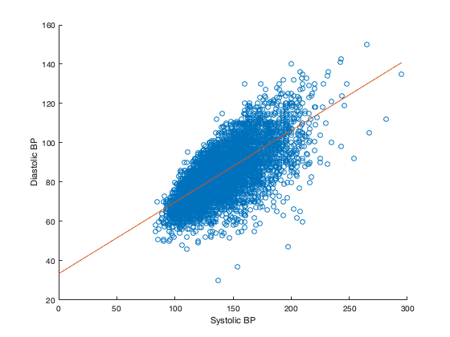

```matlab
x1 = linspace(0,max(fram.SYSBP));
y1 = polyval(p,x1);
figure
scatter(fram.SYSBP,fram.DIABP)
xlabel('Systolic BP')
ylabel('Diastolic BP')
hold on
plot(x1,y1)
hold on
```

Use polyfit once again, this time to create a quadratic model of the systolic and diastolic blood pressure relationship.

```matlab
p2 = polyfit(fram.SYSBP,fram.DIABP,2)
```

p2 = 1×3

-0.0013 0.7439 6.3051

These coefficients form the following quadratic equation:

Add this best fit line to the previous plot.

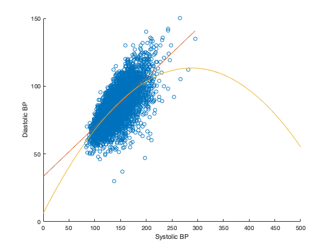

```matlab
y2 = polyval(p2,0:500);
plot(0:500,y2)
hold off
```

In regression analysis, it is important to keep the order of the model as low as possible. In this example, it appears that the first-order model actually fits the data better. The use of polynomials of higher orders can lead to incorrect evaluations.